# 贝叶斯建模brms包

## 1.2 非线性预测模型

与上面模型不同，这里强定义了贡献比的特征，包括01区间、和为1，并且采用非线性模型估计结果。

```r
# 读取数据
mergeData_s <- function(data){
  vlaidData <- data
  allTracer <- names(data)[-(1:3)]
  resfront  <- vlaidData[, lapply(.SD, unique),.SDcols=3, by="class"] %>% .[, id:=1:nrow(.)]
  outData   <- vlaidData[, lapply(.SD, mean), .SDcols=-(1:3), by="class"]
  res <- resfront[outData, on="class"] %>% .[,.SD, .SDcols=c("id", "class", "type", allTracer)]
  return(res)
}
data_merge <- fread("./data/data-scus-raw.csv") %>% mergeData_s()
# 10组指纹因子
finger_tsp  <- c("xlf", "a_star")
finger_cm   <- c("a_star", "xhf", "xlf", "cs137", "pb210", "L_star","Y", "X")
finger_cr80 <- c("a_star", "xhf", "xlf", "cs137")
finger_frn  <- c("cs137", "pb210")
finger_mag  <- c("xhf","xlf")
finger_col  <- c("X", "Y", "Z", "L_star", "a_star", "b_star", "c_star", "h_star")
finger_set  <- list(c(finger_tsp),  c(finger_cm), c(finger_cr80),
                    c(finger_frn), c(finger_mag), c(finger_col),
                    c(finger_frn, finger_mag),
                    c(finger_frn, finger_col),
                    c(finger_mag, finger_col),
                    c(finger_frn, finger_mag, finger_col))

# 指纹因子
mix <- 2             #选择使用哪个汇建模
finger <- finger_cm  #选择使用哪组复合指纹

# 筛选源汇
sou_name <- data_merge$class[1:3]
tar_name <- data_merge$class[4:6]
dat_sou  <- data_merge[1:3, .SD, .SDcols=finger] %>% t() %>% data.table() %>% set_colnames(sou_name)
dat_tar  <- data_merge[4:6, .SD, .SDcols=finger] %>% t() %>% data.table() %>% set_colnames(tar_name)

# 生成模型数据
dat_model <- cbind(dat_sou,dat_tar[,.SD,.SDcols = mix])
```

定义公式时，部分参数含义如下

- `nl = TRUE` 表示非线性模型
- `b1,b2,b3` 表示需要求解的结果，是自定义的名字
- `b ~ 1` 表示b是常数项（截距项），与自变量无关。
- `b ~ x1` 表示b是变量 x1 的线性函数。
- `b ~ x1 + x2` 表示b是 x1 和 x2 的线性函数。
- `b ~ (1 | group)` 表示b是一个随机效应，随 group 变化。

```r
# 非线性公式：简化定义
formula <- bf(
  M2 ~ (exp(b1) / (exp(b1) + exp(b2) + exp(b3))) * BS +
    (exp(b2) / (exp(b1) + exp(b2) + exp(b3))) * US +
    (exp(b3) / (exp(b1) + exp(b2) + exp(b3))) * CB,
  b1 + b2 + b3 ~ 1,
  nl = TRUE
)
```

关于先验分布选择的问题：

- 均匀分布：一种无信息先验，因为它对所有可能的值赋予相同的概率密度。
- 优点是，完全对称，没有任何偏好。
- 缺点是，范围是硬性限制，均匀分布可能不如其他分布（如正态分布）高效。
- 正态分布：是一种弱信息先验，表示你假设参数的值在 0 附近，但允许较大的灵活性。
- 优点是，没有硬性范围限制，适合参数的真实值可能超出某个区间的情况。并且由于连续光滑，计算更高效。
- 缺点是，不是完全无信息的，因为它假设参数的值更可能集中在0附近。若参数真实值远离0，则需要调整均值和标准差。

```r
# 先验
priors <- c(
  prior(normal(0, 1), nlpar = "b1"),  # b1 的先验
  prior(normal(0, 1), nlpar = "b2"),  # b2 的先验
  prior(normal(0, 1), nlpar = "b3")   # b3 的先验
)

# 经尝试，均匀分布结果经常不收敛，虽然理论上b取值-10到10可以穷举定义域中的所有可能
# priors <- c(
#   prior(uniform(-10,10), nlpar = "b1"),  # b1 的先验
#   prior(uniform(-10,10), nlpar = "b2"),  # b2 的先验
#   prior(uniform(-10,10), nlpar = "b3")   # b3 的先验
# )
```

建模求解

```r
# 模型拟合
fit_finger_nolinear <- brm(
  formula = formula,        # 非线性公式
  data = dat_model,         # 数据
  family = gaussian(),      # 正态分布假设
  prior = priors,           # 设置先验
  chains = 4,               # MCMC 链数
  iter = 2000,              # 每条链的迭代次数
  warmup = 1000,            # 预热步数
  cores = 2,                # 使用的 CPU 核心数
  control = list(adapt_delta = 0.95)  # 调整控制参数
)

# 提取模型后验样本
fixed_effects <- fixef(fit_finger_nolinear)

# 提取 beta1, beta2, beta3 的估计值
b1 <- fixed_effects[1,1];b1
b2 <- fixed_effects[2,1];b2
b3 <- fixed_effects[3,1];b3

# 求解对应贡献比
res_p1 <- exp(b1) / (exp(b1) + exp(b2) + exp(b3));res_p1
res_p2 <- exp(b2) / (exp(b1) + exp(b2) + exp(b3));res_p2
res_p3 <- exp(b3) / (exp(b1) + exp(b2) + exp(b3));res_p3
sum(res_p1, res_p2, res_p3)

# 查看MAE结果
mae <- function(a, b, c, mix){
  if(mix==1){
    p1 <- p2 <- p3 <- 1/3
  } else if(mix==2){
    p1 <- 0.4;p2 <- 0.4;p3 <- 0.2
  } else {
    p1 <- 0.6;p2 <- 0.2;p3 <- 0.2
  }
  res <- mean(c(abs(p1-a), abs(p2-b), abs(p3-c)))*100
  return(res)
}

# 结果比同情况下的scus结果更好（多次实验发现，MAE互有胜负）
mae(0.32812531, 0.60558663, 0.06628806, mix)   #scus：13.70578%
mae(res_p1, res_p2, res_p3, mix)               #brms：12.98551%
```

fit结果（注意，当Rhat超过1.05时，说明计算结果不好，得从新算）

[output not shown]

# 2. 预测均值方差

案例：基于鸢尾花数据集iris，推测setosa类鸢尾花的 Sepal.Length

模型：$Y = \beta_0+\epsilon$，因为只有截距项，所以截距的估计值为均值，随机变量的标准差也就是的标准差。

生成模型：$y_i \sim N(\mu^2,\sigma)$

先验分布：$\mu \sim N(5, 2)$, $\sigma \sim exp(1)$

这里将误差的分布定义为指数分布，有以下原因，非负性、简洁性、正则化（对较小的标准差值有更强的先验期望，倾向于认为误差不会特别大）

可用的先验分布形式还有：

1. 半正态分布(Half-Normal): `prior(normal(0, 1), class = "sigma", lb = 0)`
2. 半Cauchy 分布 (Half-Cauchy): `prior(cauchy(0, 1), class = "sigma", lb = 0)`
3. Gamma 分布: `prior(gamma(2, 0.5), class = "sigma")`
4. 学生 t 分布 (Student’s t): `prior(student_t(3, 0, 1), class = "sigma", lb = 0)`
5. Uniform 分布: `prior(uniform(0, 10), class = "sigma")`
6. Inverse-Gamma 分布: `prior(inverse_gamma(2, 0.5), class = "sigma")`

在brms中，class 参数用于指定先验分布应用于模型的哪个部分或参数类别。不同的class值对应于模型中的特定参数类型。这是brms包中定义先验分布的重要部分，因为复杂模型可能有多种参数需要指定先验。常用的`class`参数有如下可选项：

1. 对于截距项：`class = "Intercept"`
2. 对于回归系数（斜率或特定预测变量的影响）：`class = "b"`
3. 对于模型误差的标准差：`prior(exponential(1), class = "sigma")`
4. 对于分层模型中的组间标注差：`prior(cauchy(0, 2), class = "sd")`
5. 对于分层模型中的组件相关系数：`prior(lkj(2), class = "cor")`
6. 对于某些分布（如Gamma）中的形状参数：`prior(normal(2, 1), class = "shape")`
7. 对于t分布中的自由度参数：`prior(gamma(2, 0.1), class = "nu")`
8. 对于有序分类变量（ordinal models）中的阈值：`prior(normal(0, 10), class = "threshold")`

```r
# 准备数据
data <- iris %>% filter(Species == 'setosa')
# 设定先验分布
myprior <- c(prior(normal(5, 2), class = 'Intercept'),
             prior(exponential(1), class = 'sigma'))

# 建模预测（这里不运行这个模型了，太慢而且文字信息太多）
# fit_msd <- brm(Sepal.Length ~ 1, prior = myprior, data = data)

# 查看绘制后验分布和MCMC过程
# 提取后验样本
# posterior <- as_draws_df(fit_msd)
# 查看拦截项的后验分布
# hist(posterior$b_Intercept, main = "Posterior Distribution of Intercept", xlab = "Intercept")
# 或者直接画图
# plot(fit_msd)
```

fit结果如下：

```
Family: gaussian
Links: mu = identity; sigma = identity
Formula: Sepal.Length ~ 1
Data: data (Number of observations: 50)
Draws: 4 chains, each with iter = 2000; warmup = 1000; thin = 1;
total post-warmup draws = 4000

Regression Coefficients:
Estimate Est.Error l-95% CI u-95% CI Rhat Bulk_ESS Tail_ESS
Intercept     5.01      0.05     4.91     5.10 1.00     3070     2688

Further Distributional Parameters:
Estimate Est.Error l-95% CI u-95% CI Rhat Bulk_ESS Tail_ESS
sigma     0.36      0.04     0.30     0.44 1.00     3296     2605

Draws were sampled using sampling(NUTS). For each parameter, Bulk_ESS
and Tail_ESS are effective sample size measures, and Rhat is the potential
scale reduction factor on split chains (at convergence, Rhat = 1).
```

其中需要注意的是

1. Rhat: 1.00，表示 MCMC 链已收敛（理想情况下，Rhat 接近 1）。
2. Bulk_ESS, Tail_ESS: 有效样本量，分别衡量中心和尾部的样本独立性。值越高，估计越可靠。
3. NUTS: 使用 No-U-Turn Sampler (NUTS) 进行采样，NUTS 是一种高效的 Hamiltonian Monte Carlo 方法。

# 3. 比例推测

案例：假设有A，B两款药；100个服用A药的人中有30个康复了，50个服用B药的人有20个康复。我们想估算A和B两类药的有效率，以及两类药的有效率的差值。

模型：

生成模型：$y_{ia} \sim binomial(p_a)$, $y_{ib} \sim binomial(p_b)$, $p_a=\alpha$, $p_b=\alpha + \beta$

先验分布：这里使用了程序默认的先验分布。可以通过fit_pro$prior查看

注意：

1. trials() 是一个特殊的语法，用来指定二项分布的试验总次数（试验规模）
2. link在模型中被定义为恒等链接函数，如果不设定，将为logistic模型，前者成功概率为线性的，后者为01之间，更符合概率定义，但是更复杂
3. 由于没有指定先验分布，将采用brms中的默认值

```r
# 准备数据
data <- tibble(size = c(100, 50),
               success = c(30, 20),
               type = factor(c("A", "B")))

# 建模预测（这里不运行这个模型了，太慢而且文字信息太多）
# fit_pro <- brm(success|trials(size) ~ type,
#               family = binomial(link = 'identity'),
#               data = data)

# fit_pro
```

fit结果如下

```
Family: binomial
Links: mu = identity
Formula: success | trials(size) ~ type
Data: data (Number of observations: 2)
Draws: 4 chains, each with iter = 2000; warmup = 1000; thin = 1;
total post-warmup draws = 4000

Regression Coefficients:
Estimate Est.Error l-95% CI u-95% CI Rhat Bulk_ESS Tail_ESS
Intercept     0.30      0.05     0.22     0.40 1.00     4485     3168
typeB         0.10      0.08    -0.06     0.26 1.00     2083     2437

Draws were sampled using sampling(NUTS). For each parameter, Bulk_ESS
and Tail_ESS are effective sample size measures, and Rhat is the potential
scale reduction factor on split chains (at convergence, Rhat = 1).
```

结果表明：A类药品的有效率为0.3，可信区间为0.22到0.40；B类药品比A类药品有效率高0.1，可信区间为-0.06到0.26.

通过`prior_summary(fit_pro)`查看先验分布，结果如下，其中，flat表示非信息性先验，即无任何有用的先验信息。`student_t(3, 25, 7.4)`表示对截距参数的先验是一个 Student-t 分布，其中自由度为3，均值为25，标准差为7.4。class中的b表示回归系数，intercept表示截距项。source中，default表示先验是brms的默认设置，vectorized表示先验分布是什么是量化应用到多个回归系数上的

```
prior     class  coef group resp dpar nlpar lb ub       source
(flat)         b                                        default
(flat)         b typeB                             (vectorized)
student_t(3, 25, 7.4) Intercept                                        default
```

# 4. 线性回归

案例：用一元线性模型对冰淇凌销量$y_i$和气温$x_i$之间的关系进行建模。其中气温是自变量，销量是因变量。共有三个待估参数，分别是气温的系数$\beta$，截距$\alpha$，以及条件分布的标准差$\sigma$（假设为正态分布）。

模型：

生成模型：$y_i \sim N(\mu_i,\sigma)$, $\mu_i=\alpha+\beta x_i$，即线性回归模型

先验分布：默认分布

```r
data <- data.frame(
  temp = c( 11.9, 14.2, 15.2, 16.4, 17.2, 18.1,
            18.5, 19.4, 22.1, 22.6, 23.4, 25.1),
  units = c( 185L, 215L, 332L, 325L, 408L, 421L,
             406L, 412L, 522L, 445L, 544L, 614L)
)

# fit_linreg <- brm(units ~ temp, data = data)

# fit_linreg
```

fit结果如下

```
Family: gaussian
Links: mu = identity; sigma = identity
Formula: units ~ temp
Data: data (Number of observations: 12)
Draws: 4 chains, each with iter = 2000; warmup = 1000; thin = 1;
total post-warmup draws = 4000

Regression Coefficients:
Estimate Est.Error l-95% CI u-95% CI Rhat Bulk_ESS Tail_ESS
Intercept  -157.95     63.85  -282.11   -27.44 1.00     2909     2253
temp         30.01      3.36    23.08    36.70 1.00     2956     2260

Further Distributional Parameters:
Estimate Est.Error l-95% CI u-95% CI Rhat Bulk_ESS Tail_ESS
sigma    43.68     11.49    27.32    71.30 1.00     2077     2158

Draws were sampled using sampling(NUTS). For each parameter, Bulk_ESS
and Tail_ESS are effective sample size measures, and Rhat is the potential
scale reduction factor on split chains (at convergence, Rhat = 1).
```

注意，此处的Family为高斯分布，link为identity，

# 5. 泊松回归：普通形式

案例：上面冰激凌的例子中。考虑到因变量是计数型的，想把分布族从正态改为泊松。和R自带的glm函数一样，模型改写成以下形式就可以：

模型：

生成模型：$y_i \sim Poisson(\mu_i,\sigma)$, $log(\mu_n)=\alpha+\beta x_i$，即线性回归模型

先验分布：默认分布

注意：

1. 当描述某个时间段或空间范围内稀疏事件的计数的概率分布时，适合用泊松分布
2. 泊松分布的概率质量函数：$P(X=k)= {e^{-\lambda}\lambda^k \over k!}$，其中，$\lambda$是二项式分布中的$np$，也就是说，泊松分布是二项式分布的极端情况，即$n\to\infty$, $p\to0$，且$np=\lambda$的情况
3. 泊松分布的一个例子：已知每天有10个顾客，求明天有20个顾客的概率，即为dpois(20, 10)，0.001866081。这里用泊松分布的道理是，可以想象吧来客人看做二项式分布，比如划分为一个小时观测一次，则n=24，每小时来客人的概率p非常小且未知，但是如果视为泊松分布则np已经知道了是10，就可以将原二项式问题化简为泊松问题了。
4. 使用对数链接函数，则代表将线性预测值与泊松分布的均值参数相关联，即$log(\lambda)=\beta_0+\beta_1temp$，这可以保证$\lambda$一直是正值
5. 组合数计算公式：${n \choose k}=C_n^k=\frac{n!}{n!(n-k)!}$，在R语言中，计算阶乘用`factorial(3)`，计算组合用`choose(5, 2)`，计算排列用`factorial(5)/factorial(5-3)`

```r
data <- data.frame(
  temp = c( 11.9, 14.2, 15.2, 16.4, 17.2, 18.1,
            18.5, 19.4, 22.1, 22.6, 23.4, 25.1),
  units = c( 185L, 215L, 332L, 325L, 408L, 421L,
             406L, 412L, 522L, 445L, 544L, 614L)
)

fit_pos_simp <- brm(units ~ temp,
                    data = data,
                    family = poisson(link = 'log'))
```

fit结果如下

```
Family: poisson
Links: mu = log
Formula: units ~ temp
Data: data (Number of observations: 12)
Draws: 4 chains, each with iter = 2000; warmup = 1000; thin = 1;
total post-warmup draws = 4000

Regression Coefficients:
Estimate Est.Error l-95% CI u-95% CI Rhat Bulk_ESS Tail_ESS
Intercept     4.54      0.08     4.39     4.69 1.00     2552     2895
temp          0.08      0.00     0.07     0.08 1.00     3061     2742

Draws were sampled using sampling(NUTS). For each parameter, Bulk_ESS
and Tail_ESS are effective sample size measures, and Rhat is the potential
scale reduction factor on split chains (at convergence, Rhat = 1).
```

注意，原模型拟合的结果，实际上是lambda与x的关系，即y的均值与x的关系，

从回归结果中可以看出，模型对数据的拟合情况

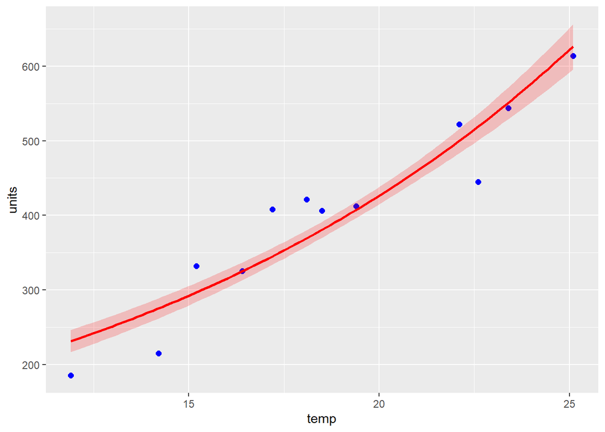

```r
# 提取 conditional_effects 数据
effects <- conditional_effects(fit_pos_simp)    # 注意若不赋值，这个函数本身就画图，但是不画数据点
effect_data <- as.data.frame(effects$temp)      # 提取与 temp 相关的效果
# 画图
ggplot() +
  geom_point(data = data, aes(x = temp, y = units), color = "blue", size = 2) +
  geom_line(data = effect_data, aes(x = temp, y = estimate__), color = "red", linewidth = 1) +
  geom_ribbon(data = effect_data, aes(x = temp, ymin = lower__, ymax = upper__),
              fill = "red", alpha = 0.2)
```

注意，虽然`fit_pos_simp`的结果可以转化为`geom_function(fun=\(x) exp(4.54+0.08*x))`，但是下面的图与上面的并不相同，原因可能是`conditional_effects` 使用了后验分布来计算均值，而 `geom_function` 使用的是点估计值

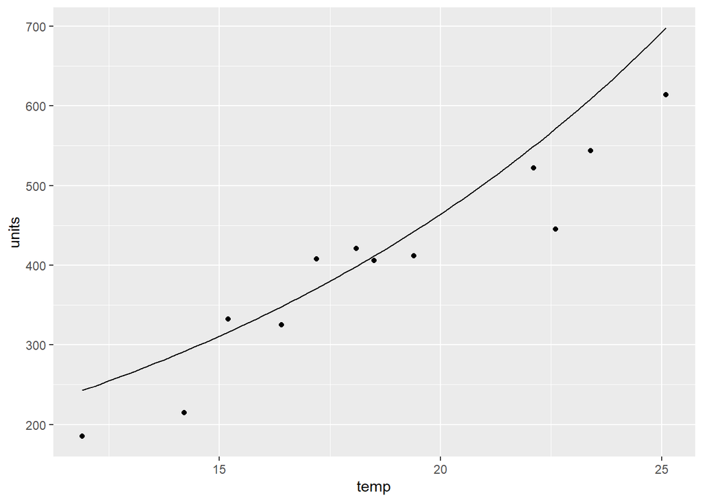

```r
ggplot(data, aes(temp, units))+
  geom_point()+
  # geom_function(fun= ~ exp(4.54+0.08*x))
  # geom_function(fun=function(x) exp(4.54+0.08*x))
  geom_function(fun=\(x) exp(4.54+0.08*x))
```

此外，贝叶斯建模后，可基于所得模型（或者说后验分布）对原样本中的冰淇凌销量进行再预测。将预测结果和实际情况比较，从而对模型的拟合情况进行评估。下图中的曲线为概率密度曲线。粗实线是样本中冰淇凌的实际销量分布情况，细实线是基于所得泊松模型多次抽样模拟的结果。

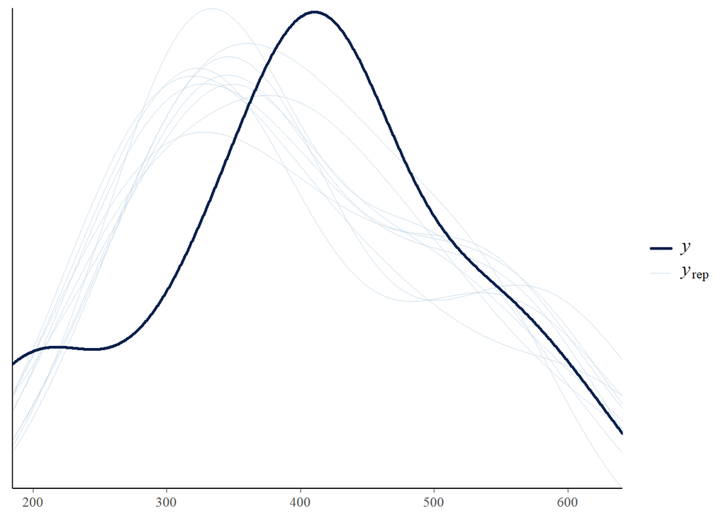

```r
# 模型预测结果的后验检验图
pp_check(fit_pos_simp)
```

# 6. 泊松分布：零膨胀模型ZIP

案例：假设景区有一个钓鱼的项目，游客团体们组队去钓鱼。游客团体有两类，一类是专心想钓鱼的，另一类是纯粹不想钓鱼的（例如只是去鱼塘欣赏风景）。前者钓到鱼的数量服从泊松分布，后者钓到鱼的数量衡等于零，导致统计的钓鱼数量分布相较泊松分布有了更多零，故名“零膨胀”。

这里使用零膨胀泊松（Zero-Inflated Poisson, ZIP）拟合数据

这个数据集是一个来自加州大学洛杉矶分校（UCLA）数字研究与教育研究所的数据集（https://stats.oarc.ucla.edu/r/dae/zip/）。它包含有关到州立公园钓鱼旅行的信息。数据已经保存到本地，其中共有8个列，其含义分别为：

- nofish：该组是否没有参与钓鱼
- livebait：是否使用活饵
- camper：是否露营
- persons：组内人数
- child：组内儿童数量
- xb,zg：未知
- count：钓到鱼的数量

注意这组数据中，nofish列没用，无论是0还是1，对应的count都有非0数据，说明矛盾的

模型：

生成模型：$y_i\sim ZIPoisson(p_i, \lambda_i)$, $p_i=\alpha_i$, $log(\lambda_i)=\alpha_\lambda+x_i^\prime \beta_\lambda$，其中$p_i$是必然捕不到鱼的概率（zi）

先验分布：默认分布

注意：

1. 本模型与上一个模型的差别，主要在family处的链接函数由`poisson`变为了`zero_inflated_poisson`

```r
# zinb <- read.csv("http://stats.idre.ucla.edu/stat/data/fish.csv")
zinb <- read.csv("./data/zinb.csv")
dat_zero <- zinb %>% mutate(camper = factor(camper, labels = c("no", "yes")))

fit_pos_zero <- brm(count ~ persons + child + camper,
                    data = dat_zero,
                    family = zero_inflated_poisson("log"))
```

fit结果如下

```
Family: zero_inflated_poisson
Links: mu = log; zi = identity
Formula: count ~ persons + child + camper
Data: dat_zero (Number of observations: 250)
Draws: 4 chains, each with iter = 2000; warmup = 1000; thin = 1;
total post-warmup draws = 4000

Regression Coefficients:
Estimate Est.Error l-95% CI u-95% CI Rhat Bulk_ESS Tail_ESS
Intercept    -1.02      0.17    -1.36    -0.68 1.00     2869     2729
persons       0.88      0.04     0.79     0.96 1.00     3016     2550
child        -1.37      0.09    -1.55    -1.18 1.00     2567     2593
camperyes     0.80      0.10     0.61     0.99 1.00     3030     2203

Further Distributional Parameters:
Estimate Est.Error l-95% CI u-95% CI Rhat Bulk_ESS Tail_ESS
zi     0.41      0.04     0.32     0.49 1.00     2775     2418

Draws were sampled using sampling(NUTS). For each parameter, Bulk_ESS
and Tail_ESS are effective sample size measures, and Rhat is the potential
scale reduction factor on split chains (at convergence, Rhat = 1).
```

结果中：

zi是ZIP模型中的零膨胀参数，表示数据中额外零值出现的概率。ZIP模型包括确定性0（零膨胀部分）以及泊松分布（普通泊松部分），用公式表示为$P(Y=0)=zi+(1-zi)P_{poisson}(Y=0)$。zi是必然情况，在本例中为41%，也就是说41%必然为0，剩余的59%才服从泊松分布，这部分仍有可能为0。

其余变量的边际效应，可用如下代码绘制出来，结果表明团队成员越多、孩子越少、带露营的团队容易捕到更多鱼：

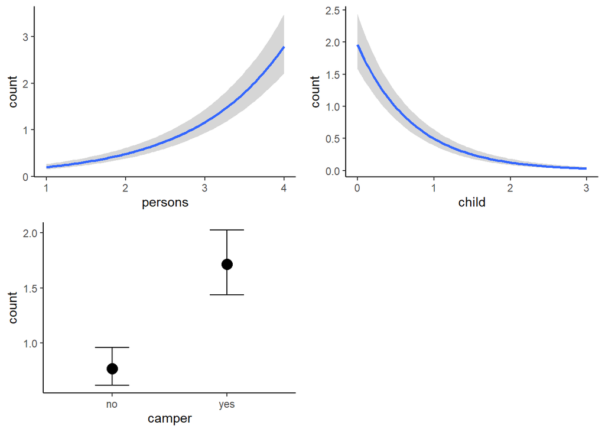

```r
ME <- conditional_effects(fit_pos_zero)
#下面主要是为了把每个变量的边际效应图都提取出来，合并后方便展示
p1 <- plot(ME, plot = FALSE)[[1]] +  theme_classic()

p2 <- plot(ME, plot = FALSE)[[2]] +  theme_classic()

p3 <- plot(ME, plot = FALSE)[[3]] +  theme_classic()

library(cowplot)
plot_grid(p1, p2, p3)
```

# 7. 泊松分布：复合形式

案例：对于上文的案例，我们可以假设，那些有孩子的团会避免去摸鱼。检验该假设需要查看孩子数量child对不摸鱼概率zi 有没有解释力。我们可以将该设定和上面零膨胀模型一起估计。brm中只需要用bf将两个公式合并在一起就可以。

模型：

先验分布：默认分布

注意，与上面模型的不同之处在于，多了一个`zi ~ child`

```r
# fit_pos_zero2 <- brm(bf(count ~ persons + child + camper, zi ~ child),
#                      data = zinb,
#                      family = zero_inflated_poisson())
#
# fit_pos_zero2
```

fit结果：

```
 Family: zero_inflated_poisson
  Links: mu = log; zi = logit
Formula: count ~ persons + child + camper
         zi ~ child
   Data: zinb (Number of observations: 250)
  Draws: 4 chains, each with iter = 2000; warmup = 1000; thin = 1;
         total post-warmup draws = 4000

Regression Coefficients:
             Estimate Est.Error l-95% CI u-95% CI Rhat Bulk_ESS Tail_ESS
Intercept       -1.08      0.19    -1.45    -0.73 1.00     2739     2803
zi_Intercept    -0.96      0.26    -1.49    -0.48 1.00     3584     2871
persons          0.89      0.05     0.80     0.99 1.00     2686     2415
child           -1.18      0.10    -1.37    -0.99 1.00     2590     2394
camper           0.78      0.09     0.59     0.97 1.00     3700     2637
zi_child         1.21      0.28     0.66     1.78 1.00     3613     2431

Draws were sampled using sampling(NUTS). For each parameter, Bulk_ESS
and Tail_ESS are effective sample size measures, and Rhat is the potential
scale reduction factor on split chains (at convergence, Rhat = 1).
```

结果表明：

1. zi_child为1.21，说明有小孩的队伍，更容易不参与捕鱼
2. `Links: mu = log; zi = logit`，表明brm默认给zi一个logit变换，因此对zi_child的解释应该也服从logit模型，即团队每多一个child，则zi概率变为原来的$exp(1.21)=3.35$倍

# 8. 广义线性模型

上面的泊松分布，实际上是广义线性模型中的一种。广义线性模型可表示为如下形式。

首先，个体$i$的因变量$y_i$来自某一个分布族family：$y_i\sim family(\theta_{1i}, \theta_{2i}, \theta_{3i}...)$

其中，$\theta_i$是该分布族的参数，因为分布族不同，参数$\theta_i$的数量也不同，例如正态分布就有两个参数，均值与方差；泊松分布只有一个参数，因为它的均值也就是方差；零膨胀模型分布有两个参数，一个是因变量恒为0的概率，一个是泊松分布的均值。

对于任意模型，都有线性组合$\eta=X\beta$，为了将该组合与分布族的参数联系起来，需要连接函数link：$link(\theta_i)=\eta_i$

因此，只需要设定好`family`和`link`参数，就可以拟合所有的广义线性模型了。brms提供了大多数常用分布族。当然，我们也可以手动自己添加分布族。

常用的模型举例如下，其他各类分布族与连接函数，可以通过??brmsfamily查看。

```r
# # 二元logistic回归
# brm(y ~ x, data = data, family = binomial(link = 'logit'))
#
# # 多分类logistic回归
# brm(y ~ x, data = data, family = multinomial(link = 'logit'))
#
# # 序次logistic回归
# brm(y ~ x, data = data, family = cumulative(link = 'logit'))
```

# 9. 嵌套结构：池化模型

Pooling model（池化模型）是一种在统计学、机器学习和计量经济学中常用的方法，它假设不同的个体或组的数据可以合并（pooled）起来以进行分析。通过池化，模型将多个数据来源的特征看作来自相同分布，从而简化建模和参数估计。

案例：这里使用的是明尼苏达州居民住宅氡含量的数据。因变量为住宅的氡含量radon，自变量为房屋楼层floor(0 = basement, 1 = first floor)。在数据结构上，作为观测对象的住房嵌套于其所在郡county。我们希望通过建模探究房屋楼层floor对氡含量radon的影响。注意这里只筛选了state为MN的样本。

模型：

基础线性模型为：$radon=\alpha+\beta_1floor+\epsilon$

```r
# 原始数据连接：https://github.com/fonnesbeck/multilevel_modeling/blob/master/data/srrs2.dat
srrs2 <- read.table("./data/srrs2.dat", header = T, sep = ',') %>%
  as_tibble() %>%
  filter(state == 'MN') %>%
  mutate(radon = ifelse(activity == 0, .1, activity), county = factor(county))

# 频率法建模
# fit_pool_freq <- lm(radon ~ floor, data = srrs2)

# 贝叶斯建模
# fit_pool_baye <- brm(radon ~ floor, data = srrs2)
```

fit结果对比，差异不大

频率模型

```
Call:
lm(formula = radon ~ floor, data = srrs2)

Coefficients:
(Intercept)        floor
      5.066       -1.785
```

贝叶斯模型

```
 Family: gaussian
  Links: mu = identity; sigma = identity
Formula: radon ~ floor
   Data: srrs2 (Number of observations: 919)
  Draws: 4 chains, each with iter = 2000; warmup = 1000; thin = 1;
         total post-warmup draws = 4000

Regression Coefficients:
          Estimate Est.Error l-95% CI u-95% CI Rhat Bulk_ESS Tail_ESS
Intercept     5.06      0.16     4.75     5.38 1.00     5085     3081
floor        -1.79      0.40    -2.58    -1.01 1.00     4125     3157

Further Distributional Parameters:
      Estimate Est.Error l-95% CI u-95% CI Rhat Bulk_ESS Tail_ESS
sigma     4.44      0.11     4.23     4.65 1.00     4670     3218

Draws were sampled using sampling(NUTS). For each parameter, Bulk_ESS
and Tail_ESS are effective sample size measures, and Rhat is the potential
scale reduction factor on split chains (at convergence, Rhat = 1).
```

# 10. 嵌套结构：固定效应模型

模型：

生成模型：$radon=\alpha+\beta_1floor+\beta_2county_{ANOKA}+\beta_3county_{BECKER}+...+\beta_{85}county_{YELLOW MEDICINE}$

该模型假设每个郡都有一个独立的截距，或者说自带一个固定效应。其缺陷在于，当某郡的住房样本量比较小时，对该郡固定效应的估计就很容出现极端值，或者说估计不准确（尽管在保证参数无偏性上，固定效应比随机效应的设定更具优势）。

```r
# 频率法建模
# fit_pool_freq_fix <- lm(radon ~ floor+county, data = srrs2)

# 贝叶斯建模
# fit_pool_baye_fix <- brm(radon ~ floor+county, data = srrs2)
```

fit结果对比，差异不大

频率模型

```
Call:
lm(formula = radon ~ floor + county, data = srrs2)

Coefficients:
               (Intercept)                       floor  countyANOKA
                    2.7114                     -2.5455                      0.3970
countyBECKER                countyBELTRAMI              countyBENTON
                    2.3190                      2.7718                      1.7000
countyBIG STONE             countyBLUE EARTH            countyBROWN
                    2.2220                      5.3023                      4.3864
（略）
```

贝叶斯模型

```
 Family: gaussian
  Links: mu = identity; sigma = identity
Formula: radon ~ floor + county
   Data: srrs2 (Number of observations: 919)
  Draws: 4 chains, each with iter = 2000; warmup = 1000; thin = 1;
         total post-warmup draws = 4000

Regression Coefficients:
                     Estimate Est.Error l-95% CI u-95% CI Rhat Bulk_ESS Tail_ESS
Intercept                2.71      2.12    -1.63     6.63 1.10       34      166
floor                   -2.55      0.42    -3.37    -1.71 1.00     3828     2882
countyANOKA              0.38      2.19    -3.75     4.75 1.10       35      181
countyBECKER             2.28      3.19    -4.01     8.46 1.04       71      567
countyBELTRAMI           2.79      2.66    -2.22     8.16 1.06       51      350
countyBENTON             1.69      2.97    -4.18     7.50 1.05       53      433
countyBIGSTONE           2.20      3.19    -4.03     8.38 1.04       71      591
countyBLUEEARTH          5.28      2.40     0.86    10.04 1.08       42      223
countyBROWN              4.42      2.95    -1.31    10.19 1.05       58      424
（略）
```

# 11. 嵌套结构：随机效应模型

模型设定

$radon_i\sim N(\alpha_{j[i]}+\beta_{1j[i]}floor, \sigma^2)$,
$$\binom{\alpha_j}{\beta_{1j}}\sim
N(\binom{\mu_{\alpha_j}}{\mu_{\beta_{1j}}}, \begin{pmatrix}
\sigma^2_{\alpha_j} & \rho\alpha_j\beta_{1j} \\ \rho\beta_{1j} &
\sigma^2_{\beta_{1j}} \\ \end{pmatrix})$$
, for county $j = 1,2,3,...,J$

顾名思义，就是对截距和系数项设置了随机效应，假设不同郡的系数和截距都不一样。该设定和固定效应的区别是，我们并不对每个郡的截距与斜率进行单独估计，而是充分利用了数据总体所包含的信息。简单来说，就是每个县都有自己的均值，但是一个县获取的信息可以帮助我们估计其他县的值。

注意，设置随机效应的方法为`(1 + floor|county)`，代表对截距项以及floor项在county层面设置了随机效应

```r
# 频率法建模
library(lme4)
fit_pool_freq_rad <- lmer(radon ~ floor + (1 + floor|county), data = srrs2)

# 贝叶斯模型
# fit_pool_baye_rad <-  brm(formula = radon ~ floor + (1+floor|county), data = srrs2)
# coef(fit_pool_baye_rad)               #可以查看对不同郡截距与系数的估计。
# as_draws_df(fit_pool_baye_rad)        #可以直接提取后验分布样本。
```

fit结果对比

频率模型

```
Linear mixed model fit by REML ['lmerMod']
Formula: radon ~ floor + (1 + floor | county)
   Data: srrs2
REML criterion at convergence: 5273.721
Random effects:
 Groups   Name        Std.Dev. Corr
 county   (Intercept) 2.246
          floor       1.910    -0.98
 Residual             4.076
Number of obs: 919, groups:  county, 85
Fixed Effects:
(Intercept)        floor
      5.774       -2.473
```

贝叶斯模型

```
 Family: gaussian
  Links: mu = identity; sigma = identity
Formula: radon ~ floor + (1 + floor | county)
   Data: srrs2 (Number of observations: 919)
  Draws: 4 chains, each with iter = 2000; warmup = 1000; thin = 1;
         total post-warmup draws = 4000

Multilevel Hyperparameters:
~county (Number of levels: 85)
                     Estimate Est.Error l-95% CI u-95% CI Rhat Bulk_ESS Tail_ESS
sd(Intercept)            2.17      0.31     1.59     2.81 1.00     1242     1811
sd(floor)                1.92      0.54     0.87     2.98 1.00     1382     1441
cor(Intercept,floor)    -0.84      0.14    -0.99    -0.50 1.00     2038     2068

Regression Coefficients:
          Estimate Est.Error l-95% CI u-95% CI Rhat Bulk_ESS Tail_ESS
Intercept     5.74      0.32     5.12     6.37 1.00     1291     2461
floor        -2.37      0.47    -3.30    -1.43 1.00     2716     3104

Further Distributional Parameters:
      Estimate Est.Error l-95% CI u-95% CI Rhat Bulk_ESS Tail_ESS
sigma     4.08      0.10     3.88     4.28 1.00     5690     2613

Draws were sampled using sampling(NUTS). For each parameter, Bulk_ESS
and Tail_ESS are effective sample size measures, and Rhat is the potential
scale reduction factor on split chains (at convergence, Rhat = 1).
```

# 12. 自定义非线性模型

`brms`包模型的主要结构包括：

1. 因变量的分布`family`：$y_i\sim family(\theta_{1i}, \theta_{2i}, \theta_{3i}...)$
2. 连接函数`link`：$link(\theta_i)=\eta_i$
3. 自变量因变量的关系式，例如线性组合：$\eta_i=X_i\beta$

其中，自变量与因变量的关系，可以自定义，例如下面的数据中，有以下关系：

1. 分布族：$y_i\sim N(\theta_i,1)$
2. 连接函数：$\theta_i=\eta_i$
3. 关系式：$\eta_i=b_iexp(b_2x_i)$

注意：

1. `bf`表示贝叶斯模型公式，支持指定固定效应、随机效应以及非线性关系。
2. `nl=TRUE`，即模型是非线性的，是自己设定的$\eta$形式
3. `b1 ~ 1`, `b2 ~ 1`告诉程序，b1和b2都是待估参数，且不需要用其他变量对这两个参数进行估计（即只有截距~1）。
4. `prior`函数，将`b1`，`b2`的先验函数，定义为正态分布

```r
# 生成数据
b <- c(2, 0.75)
x <- rnorm(100)
y <- rnorm(100, mean = b[1] * exp(b[2] * x))
dat_custom <- data.frame(x, y)

# 设定先验分布
prior1 <- prior(normal(1, 2), nlpar = "b1") + prior(normal(0, 2), nlpar = "b2")

# 拟合
# fit_custom <- brm(bf(y ~ b1 * exp(b2 * x),
#                      nl = TRUE,
#                      b1 ~ 1,
#                      b2 ~ 1),
#                   data = dat_custom,
#                   prior = prior1)
```

fit结果：

```
 Family: gaussian
  Links: mu = identity; sigma = identity
Formula: y ~ b1 * exp(b2 * x)
         b1 ~ 1
         b2 ~ 1
   Data: dat_custom (Number of observations: 100)
  Draws: 4 chains, each with iter = 2000; warmup = 1000; thin = 1;
         total post-warmup draws = 4000

Regression Coefficients:
             Estimate Est.Error l-95% CI u-95% CI Rhat Bulk_ESS Tail_ESS
b1_Intercept     1.90      0.10     1.69     2.10 1.00     1727     2057
b2_Intercept     0.79      0.03     0.74     0.85 1.00     1726     2194

Further Distributional Parameters:
      Estimate Est.Error l-95% CI u-95% CI Rhat Bulk_ESS Tail_ESS
sigma     1.00      0.07     0.87     1.16 1.00     2213     2035

Draws were sampled using sampling(NUTS). For each parameter, Bulk_ESS
and Tail_ESS are effective sample size measures, and Rhat is the potential
scale reduction factor on split chains (at convergence, Rhat = 1).
```

结果表明，b1的估计值为1.90，b2的估计值为0.79

# 13. 官方案例，二项基准模型

Case data的数据来自lme4包，描述了非洲牛CBPP病的传播。其中有四个变量：

- period: the time period
- herd: a factor identifying the cattle herd
- incidence: number of new disease cases for a given herd and time period
- size: the herd size at the beginning of a given time period

基准模型：

普通二项式模型，对于事件$y$（本例中为incidence）和总试验次数$T$（size），二项分布的概率质量函数为$P(y|T,p)= \binom{T}{y}p^y(1-p)^{T-y}$，其中$p_i$是概率。景点的二项式模型中，使用logit-scale预测$p_i$，即对每个观测值$i$，成功的概率为$p_i=\frac{exp(\eta_i)}{1+exp(\eta_i)}$，其中$\eta_i$是观测值$i$的线性预测项。

在brms包中，上述过程可表示为：

其中：

1. incidence：响应变量，表示受感染的个数
2. size：二项分布的试验次数，用trials(size)表示，用`|`可以看作是`incidence/size`，即成功率
3. period：固定效应，表示事件发生率会随着时期变化，是对响应变量的全局性、确定性影响
4. herd：随机效应项，表示按herd分组的随机截距，其中1表示截距项，随机效应引起的是非全局性、随机性的变异
5. 本例中模型为：$\eta_i=\beta_0+\mu_i+\beta_2period_i$，其中$\mu_i$的截距随机是由herd提供的，并且$\mu_i\sim N(0, \sigma^2)$
6. 若无随机效应：$\eta_i=\beta_0+\beta_1period_i$

```r
# fit_offical1 <- brm(incidence | trials(size) ~ period + (1|herd),
#                     data = cbpp,
#                     family = binomial())
```

fit结果为

```
 Family: binomial
  Links: mu = logit
Formula: incidence | trials(size) ~ period + (1 | herd)
   Data: cbpp (Number of observations: 56)
  Draws: 4 chains, each with iter = 2000; warmup = 1000; thin = 1;
         total post-warmup draws = 4000

Multilevel Hyperparameters:
~herd (Number of levels: 15)
              Estimate Est.Error l-95% CI u-95% CI Rhat Bulk_ESS Tail_ESS
sd(Intercept)     0.76      0.23     0.40     1.29 1.00     1347     1893

Regression Coefficients:
          Estimate Est.Error l-95% CI u-95% CI Rhat Bulk_ESS Tail_ESS
Intercept    -1.40      0.26    -1.95    -0.92 1.00     1852     2195
period2      -1.01      0.31    -1.64    -0.39 1.00     4916     3139
period3      -1.15      0.33    -1.83    -0.53 1.00     4634     3196
period4      -1.61      0.44    -2.56    -0.79 1.00     4632     3188

Draws were sampled using sampling(NUTS). For each parameter, Bulk_ESS
and Tail_ESS are effective sample size measures, and Rhat is the potential
scale reduction factor on split chains (at convergence, Rhat = 1).
```

结果表明：

1. sd(Intercept)估计值为0.76，即$\mu_i$的标准差估计值为0.76，即$\eta_i$在对数几率空间中，约有 95%的值落在$\beta_0\pm2\times0.76$范围内。
2. period的估计值含义，其中Intercept为`period1`，-1.40的意义是$\eta=-1.40$，则带入概率的link式$p_i=\frac{exp(\eta_i)}{1+exp(\eta_i)}$，求得的period1的p等于0.20，类似的period2时，$\eta=-1.40-1.01=-2.41$带入公式得p2=0.08，同理p3=0.075（也是-1.40-1.15），p4=0.047（-1.40-1.61）
3. 至于为什么$p_i$和$\eta_i$的link为如上形式，因为本模型默认使用logit连接函数，即$p_i=\frac{exp(\eta_i)}{1+exp(\eta_i)}$，它是$\eta=log(\frac{p}{1-p})$的反函数
4. 根据结果中的$\eta$求得的$p$，是患病的概率`incidence`

# 14. 官方案例，自定义分布

上面模型的一个缺点是，由于采用了线性模型，则方差是固定的为$Var(y_i)=T_ip_i(1-p_i)$，所有超过这个值的方差都不能被模型所解释，这被称作过度散布。可以通过自定义分布来解决。

模型：

Beta-binomial model，是广义的二项分布，有额外的参数处理过度散步。在Beta二项分布中，不再直接估计概率$p_i$，而是定义了两个Beta分布的超参数，即$\alpha>0$，$\beta>0$。则$p_i\sim Beta(\alpha_i, \beta_i)$。

由于$\alpha_i$和$\beta_i$两参数的含义非常难解释，因此写成另一种形式，另$\mu\in[0,1]$，$\phi>0$，且$\alpha_i=\mu_i\phi_i$，$\beta_i=\mu_i(1-\phi_i)$，则原Beta分布化简为$p_i\sim Beta(\mu\phi, (1-\mu)\phi)$。

因此，参数$\mu$和$\phi$指定了均值和精度参数，并且$\mu_i=\frac{exp(\eta_i)}{1+exp(\eta_i)}$，于是仍然通过转换后的线性预测器（如原始二项模型）来预测预期概率，但可以通过参数$\phi$解释过度分散问题。

然后使用`custom_family`定义分布族

```r
beta_binomial2 <- custom_family(
  "beta_binomial2",               #自定义分布族名字
  dpars = c("mu", "phi"),         #分布族需要哪些参数？
  links = c("logit", "log"),      #分布族参数的连接函数
  lb = c(0, 0),                   #参数的下限
  ub = c(1, NA),                  #参数上限
  type = "int",                   #分布的类型：连续还是离散？
  vars = "vint1[n]"              #其他不需要估计的参数（命名为vint）——在本例中，即独立重复实验的次数T
)
```

其次，由于brms 是对Rstan进行的封装，所以自定义分布族后，需要给出（1）分布族密度的对数，以及（2）生成随机样本的函数在Rstan 中的表达式，而对于beta_binomial2分布，这是直接的，因为已经实现了有序的beta_binomial分布。对于模型拟合,我们只需要`beta_binomial2_lpmf`,但是`beta_binomial2_rng`在处理后会很方便。

```r
stan_funs <- "
  real beta_binomial2_lpmf(int y, real mu, real phi, int T) {
    return beta_binomial_lpmf(y | T, mu * phi, (1 - mu) * phi);
  }
  int beta_binomial2_rng(real mu, real phi, int T) {
    return beta_binomial_rng(T, mu * phi, (1 - mu) * phi);
  }
"
```

下面这个函数，提供了试验次数的信息。为了提供有关试验次数（一个整数变量）的信息，我们将使用加法参数`vint()`，该参数只能在自定义族中使用。类似地，如果我们需要包含实际数据的额外向量，我们将使用`vreal()`。实际上，对于这个特殊的例子，我们可以更优雅地应用加法参数`trials()`，而不是在基本的二项模型中使用`vint()`。然而，由于目前的小插图是为了给主题的总体概述，我们将采用更一般的方法。

```r
# 传递给Stan的用户定义变量
stanvars <- stanvar(scode = stan_funs, block = "functions")
```

最后正常拟合就可以了：

```r
fit_offical2 <- brm(
  incidence | vint(size) ~ period + (1|herd), data = cbpp,
  family = beta_binomial2, stanvars = stanvars
)
```

fit结果：

```
 Family: beta_binomial2
  Links: mu = logit; phi = identity
Formula: incidence | vint(size) ~ period + (1 | herd)
   Data: cbpp (Number of observations: 56)
  Draws: 4 chains, each with iter = 2000; warmup = 1000; thin = 1;
         total post-warmup draws = 4000

Multilevel Hyperparameters:
~herd (Number of levels: 15)
              Estimate Est.Error l-95% CI u-95% CI Rhat Bulk_ESS Tail_ESS
sd(Intercept)     0.38      0.26     0.02     0.97 1.01      991     1798

Regression Coefficients:
          Estimate Est.Error l-95% CI u-95% CI Rhat Bulk_ESS Tail_ESS
Intercept    -1.35      0.26    -1.87    -0.85 1.00     3541     2346
period2      -0.99      0.41    -1.83    -0.22 1.00     3164     2992
period3      -1.25      0.45    -2.18    -0.42 1.00     3296     2719
period4      -1.53      0.52    -2.63    -0.59 1.00     3403     2886

Further Distributional Parameters:
    Estimate Est.Error l-95% CI u-95% CI Rhat Bulk_ESS Tail_ESS
phi    17.63     17.69     5.55    57.66 1.00     1400     1186

Draws were sampled using sampling(NUTS). For each parameter, Bulk_ESS
and Tail_ESS are effective sample size measures, and Rhat is the potential
scale reduction factor on split chains (at convergence, Rhat = 1).
```

结果表明，period系数的不确定性比基准模型的不确定性要大一些，这是模型中加入了过色散参数$\phi$的结果。除此之外，结果看起来非常相似。

三个有用的需要用户额外输入的函，数这些方法不仅对其自身有用，还为其他后处理方法提供基础。例如，通过`loo`方法实现的近似留一交叉验证（LOO-CV）就依赖于`log_lik`函数：

1. posterior_epred：计算预测均值
2. posterior_predict：计算预测响应值
3. log_lik：计算对数似然值

## 14.1. 建立log_lik函数

为了能够进行`log_lik`计算，用户需要为自定义模型定义一个`log_lik_<family-name>`函数，本例中，对于 Beta-Binomial 模型，函数应命名为`log_lik_beta_binomial2`，它需要两个输入参数，

- i：表示观测值（observation）。
- prep：包含预处理数据和模型参数的对象（其中数据存储在`prep$data`中，模型参数存储在`prep$dpars`中）。

通常，预测参数（如mu）是一个S×N矩阵（其中S是后验样本数量，N是观测数量），而未预测的参数（如 $\phi$）是一个大小为N的向量。

有两种方法定义log-likelihood函数，其中一种是自己定义，优点是稳定且在自定义family时的唯一方法；另一种是通过暴露stan中的函数，使函数可以在R中使用，优点是方便

```r
# 使用Stan暴露函数的方法，后期比如pp_check(fit_offical2)中会用到暴露的函数
expose_functions(fit_offical2, vectorize = TRUE)

# 使用自定义方法
log_lik_beta_binomial2 <- function(i, prep) {
  mu <- brms::get_dpar(prep, "mu", i = i)
  phi <- brms::get_dpar(prep, "phi", i = i)
  trials <- prep$data$vint1[i]
  y <- prep$data$Y[i]
  beta_binomial2_lpmf(y, mu, phi, trials)
}
```

定义log-likelihood函数后，就可以比较两个模型的拟合效果了

```r
# 模型对比
# loo(fit_offical1, fit_offical2)
```

对比结果：

```
Output of model 'fit_offical1':

Computed from 4000 by 56 log-likelihood matrix.

         Estimate   SE
elpd_loo   -100.6 10.4
p_loo        22.7  4.7
looic       201.2 20.9
------
MCSE of elpd_loo is NA.
MCSE and ESS estimates assume MCMC draws (r_eff in [0.4, 1.6]).

Pareto k diagnostic values:
                         Count Pct.    Min. ESS
(-Inf, 0.7]   (good)     48    85.7%   264
   (0.7, 1]   (bad)       6    10.7%   <NA>
   (1, Inf)   (very bad)  2     3.6%   <NA>
See help('pareto-k-diagnostic') for details.

Output of model 'fit_offical2':

Computed from 4000 by 56 log-likelihood matrix.

         Estimate   SE
elpd_loo    -95.0  8.3
p_loo        10.8  2.0
looic       190.0 16.5
------
MCSE of elpd_loo is NA.
MCSE and ESS estimates assume MCMC draws (r_eff in [0.4, 1.1]).

Pareto k diagnostic values:
                         Count Pct.    Min. ESS
(-Inf, 0.7]   (good)     55    98.2%   118
   (0.7, 1]   (bad)       1     1.8%   <NA>
   (1, Inf)   (very bad)  0     0.0%   <NA>
See help('pareto-k-diagnostic') for details.

Model comparisons:
             elpd_diff se_diff
fit_offical2  0.0       0.0
fit_offical1 -5.6       4.5
```

结果表明，较大的ELPD模型拟合更好，则第二个beta-binomial模型优于基准模型

## 14.2. 建立posterior_predict函数

```r
posterior_predict_beta_binomial2 <- function(i, prep, ...) {
  mu <- brms::get_dpar(prep, "mu", i = i)
  phi <- brms::get_dpar(prep, "phi", i = i)
  trials <- prep$data$vint1[i]
  beta_binomial2_rng(mu, phi, trials)
}
```

后验检查

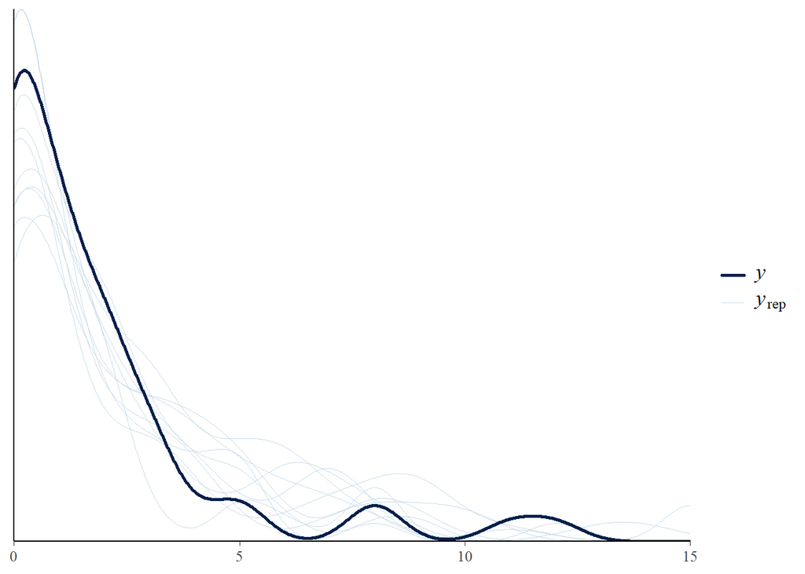

```r
# 模型预测结果的后验检验图
pp_check(fit_offical2)
```

## 14.3. 建立posterior_epred函数

```r
posterior_epred_beta_binomial2 <- function(prep) {
  mu <- brms::get_dpar(prep, "mu")
  trials <- prep$data$vint1
  trials <- matrix(trials, nrow = nrow(mu), ncol = ncol(mu), byrow = TRUE)
  mu * trials
}
```

直接依赖`posterior_epred`的后处理过程是`conditional_effects`，可以可视化预测器的效果

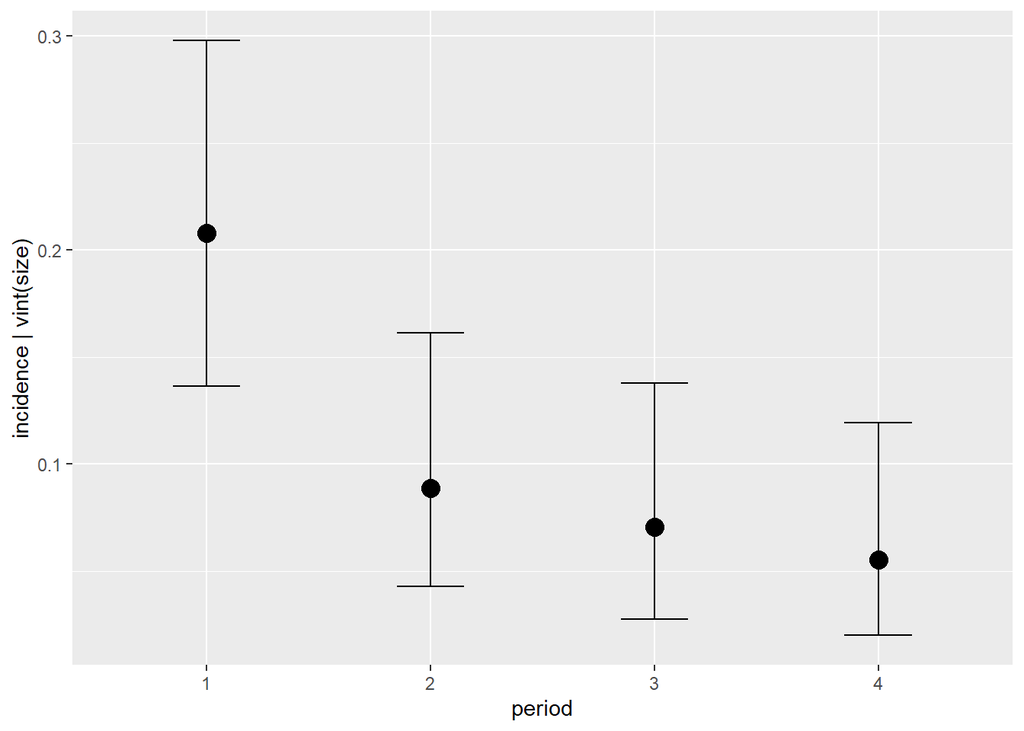

```r
# 预测效果可视化
# 为了便于解释，我们将size设置为1，以便上图的y轴表示概率。
conditional_effects(fit_offical2, conditions = data.frame(size = 1))
```